# R Notebook

```r
library("readxl")
library("tidyverse")
require("tidyverse")
library("writexl")
library("psych")

library("nortest") ###REALIZA 5 PRUEBAS DE NORMALIDAD###
library("moments") ###REALIZA 1 PRUEBA DE NORMALIDAD###

library("psych")
```

```r
basedatos <- read_excel("PersonasConNegocios_ENIGH2022.xlsx")
```

Recodificacion de la variable ‘Numero de empleados’, se categoriza usando as.factor para poder usarlos mas adelante no como numeros

```r
basedatos <- basedatos %>% mutate(tamano = as.factor(case_when(
  Numero_Empleados == '1 a 9' ~ 1,
  Numero_Empleados == '10 a 99' ~ 2,
    Numero_Empleados == '100 a 199' ~ 3,
    Numero_Empleados == '+200' ~ 4,
    TRUE ~ 0
)))
```

```r
summary(basedatos$tamano)
```

```
    0     1     2     3     4
   59 10159   506    59   171
```

```r
table(basedatos$Numero_Empleados)
```

```
     +200     1 a 9   10 a 99 100 a 199   No sabe
      171     10159       506        59        59
```

## 1. Pruebas de normalidad

Tiempo laborando en anios B1P02B06A

```r
basedatos <- basedatos %>% mutate(datos_normales = rnorm(n()))
#la parte de n() hace que sea basado en el numero de filas haciendo mas dinamico
```

```r
plot(density(basedatos$datos_normales), lwd=3, col='blue', main='Gráfico de densidad', las=1,
     xlab='', ylab='Densidad')
lines(density(basedatos$B1P02B06A), lwd=3, col='red')
```

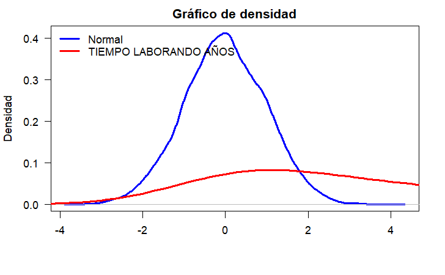

```r
legend('topleft', legend=c('Normal', 'TIEMPO LABORANDO AÑOS'),
       lwd=3, col=c('blue', 'red'), bty='n')
```

### 1.1 Graficando en qqplot

A Q-Q plot is a graphical tool used to assess whether a dataset follows a theoretical distribution, often a normal distribution.

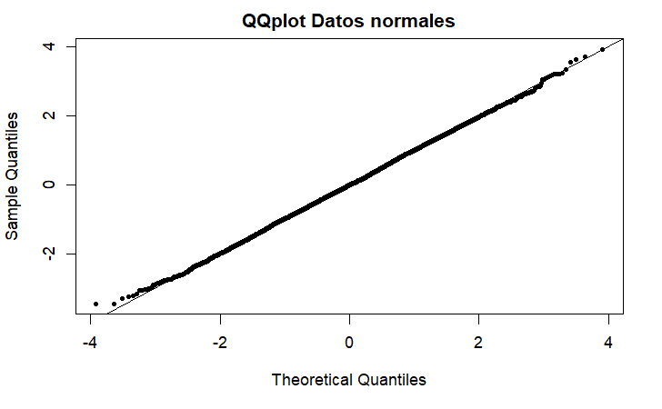

```r
qqnorm(basedatos$datos_normales, pch=20,
       main='QQplot Datos normales')
qqline(basedatos$datos_normales)
```

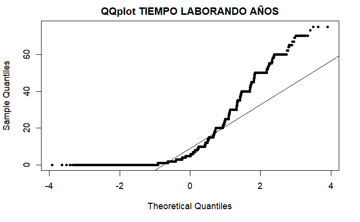

```r
qqnorm(basedatos$B1P02B06A, pch=20,
       main='QQplot TIEMPO LABORANDO AÑOS')
qqline(basedatos$B1P02B06A)
```

### 1.2 Pruebas de Hipotesis

#### 1.2.1 Pruebas de normalidad

- H0: La muestra proviene de una distribución normal.
- H1: La muestra no proviene de una distribución normal.

Para pruebas de normalidad siempre se plantean así las hipótesis. Pruebas de Normalidad del Paquete “nortest”

##### 1.2.1.1 Prueba Anderson-Darling

```r
ad.test(basedatos$B1P02B06A)
```

```
    Anderson-Darling normality test

data:  basedatos$B1P02B06A
A = 765.87, p-value < 2.2e-16
```

```r
ad.test(basedatos$datos_normales)
```

```
    Anderson-Darling normality test

data:  basedatos$datos_normales
A = 0.63692, p-value = 0.09679
```

Caso 1: El valor alto de A sugiere una desviacion significativa de la distribucion normal. El valor p es muy pequeño, lo cual indica que se refuta la hipoteis nula; por lo tanto, La muestra no proviene de una distribución normal

Caso 2: El valor de A es relativamente pequeño, por lo que la muestra es cercana a la distribucion normal. Ya que el valor p es mayor que el nivel de significacia (0.05, 0.01), se acepta la hipotesis nula, por lo que los datos no se desvian significativamente de la distribucion normal.

##### 1.2.1.2 Prueba de Cramer-von Mises

Prueba de Cramer-von MEs útil para pequeñas muestras y usa los momentos como criterio.

```r
cvm.test(basedatos$B1P02B06A)
```

```
    Cramer-von Mises normality test

data:  basedatos$B1P02B06A
W = 134.96, p-value = 7.37e-10
```

```r
cvm.test(basedatos$datos_normales)
```

```
    Cramer-von Mises normality test

data:  basedatos$datos_normales
W = 0.11316, p-value = 0.0743
```

Caso 1: El valor de W es grande. El valor p es muy pequeño, por lo que se rechazaria la hipotesis nula.

Caso 2: El valor de W es relativamente pequeño. El valor p es un poco mayor a la significacia de 0.05 pero menor a 0.10. Por lo tanto no se rechaza la hipotesis nula.

##### 1.2.1.3 Prueba de Lilliefors (Kolmogorov-Smirnov)

```r
lillie.test(basedatos$B1P02B06A)
```

```
    Lilliefors (Kolmogorov-Smirnov) normality test

data:  basedatos$B1P02B06A
D = 0.20508, p-value < 2.2e-16
```

```r
lillie.test(basedatos$datos_normales)
```

```
    Lilliefors (Kolmogorov-Smirnov) normality test

data:  basedatos$datos_normales
D = 0.0094016, p-value = 0.02992
```

##### 1.2.1.4 Prueba de Pearson chi-square

Basada en una distribución Ji cuadrado y que corresponde a una prueba de bondad de ajuste.

```r
pearson.test(basedatos$B1P02B06A)
```

```
    Pearson chi-square normality test

data:  basedatos$B1P02B06A
P = 55034, p-value < 2.2e-16
```

```r
pearson.test(basedatos$datos_normales)
```

```
    Pearson chi-square normality test

data:  basedatos$datos_normales
P = 97.73, p-value = 0.08667
```

##### 1.2.1.5 Prueba de Shapiro-Francia

```r
sf.test(basedatos$B1P02B06A[1:5000])
```

```
    Shapiro-Francia normality test

data:  basedatos$B1P02B06A[1:5000]
W = 0.79621, p-value < 2.2e-16
```

```r
sf.test(basedatos$datos_normales[1:5000])
```

```
    Shapiro-Francia normality test

data:  basedatos$datos_normales[1:5000]
W = 0.99968, p-value = 0.5584
```

##### 1.2.1.6 Pruebas de Normalidad del Paquete “moments” Prueba de Agostino

```r
agostino.test(basedatos$B1P02B06A)
```

```
    D'Agostino skewness test

data:  basedatos$B1P02B06A
skew = 1.6085, z = 49.9468, p-value < 2.2e-16
alternative hypothesis: data have a skewness
```

```r
agostino.test(basedatos$datos_normales)
```

```
    D'Agostino skewness test

data:  basedatos$datos_normales
skew = -0.00062014, z = -0.02651550, p-value = 0.9788
alternative hypothesis: data have a skewness
```

##### 1.2.1.7 Funciones incluidas en los paquetes básicos de R. Prueba de Shapiro-Wilk

Es más poderosa cuando se compara con otras pruebas de normalidad cuando la muestra es pequeña.

```r
shapiro.test(basedatos$B1P02B06A[1:5000])
```

```
    Shapiro-Wilk normality test

data:  basedatos$B1P02B06A[1:5000]
W = 0.79613, p-value < 2.2e-16
```

```r
shapiro.test(basedatos$datos_normales[1:5000])
```

```
    Shapiro-Wilk normality test

data:  basedatos$datos_normales[1:5000]
W = 0.99965, p-value = 0.559
```

#### 1.2.2 Pruebas de hipotesis para medias univariables

Se puede separar en parametrico y no parametrico

- H0: mu=a
- H1: mu distinto de a
- H0: mu<a
- H1: mu>a

**no es necesario que sea mayor o igual, esto es porque es una dist continua (dijo que venia de la t-student), porque me quedaria solamente un punto y el area bajo la curva del punto es cero.

- H0: mu>a
- H1: mu<a

*la conclusion es la misma pero el numero no va a ser el mismo, son tres formas de plantear el problema

pvalor es la probabilidad que H0 sea verdad

```r
# promedio Años trabajando
mean(basedatos$B1P02B06A)
```

```r
# promedio  EDAD
mean(basedatos$B1P00A03)
```

```r
t.test(basedatos$B1P02B06A, basedatos$B1P00A03, alternative='two.sided',conf.level = 0.95) #H0 ambas medias son iguales
```

```
    Welch Two Sample t-test

data:  basedatos$B1P02B06A and basedatos$B1P00A03
t = -166.08, df = 21598, p-value < 2.2e-16
alternative hypothesis: true difference in means is not equal to 0
95 percent confidence interval:
 -33.01740 -32.24716
sample estimates:
mean of x mean of y
 11.23873  43.87101
```

```r
t.test(basedatos$B1P02B06A, basedatos$B1P00A03, alternative='greater',conf.level = 0.95) #H0 la media de B1P02B06A es menor que la media de B1P00A03
```

```
    Welch Two Sample t-test

data:  basedatos$B1P02B06A and basedatos$B1P00A03
t = -166.08, df = 21598, p-value = 1
alternative hypothesis: true difference in means is greater than 0
95 percent confidence interval:
 -32.95548       Inf
sample estimates:
mean of x mean of y
 11.23873  43.87101
```

```r
t.test(basedatos$B1P02B06A, basedatos$B1P00A03, alternative='less',conf.level = 0.95) #H0 la media de B1P02B06A es mayor que la media de B1P00A03
```

```
    Welch Two Sample t-test

data:  basedatos$B1P02B06A and basedatos$B1P00A03
t = -166.08, df = 21598, p-value < 2.2e-16
alternative hypothesis: true difference in means is less than 0
95 percent confidence interval:
      -Inf -32.30908
sample estimates:
mean of x mean of y
 11.23873  43.87101
```

- t es la t-estadistica de la prueba, mide el tamaño de la diferencia relativa a la variacion de los datos de la muestra. Un valor absoluto grande indica una diferencia significativa entre las medias.
- df son los grados de libertad, la prueba se ajusta para varianzas distintas y usa distintos grados de libertad a la prueba t regular.
- p-value, si es menor a 0.05 (o cualquier nivel de significacia escogido) se rechaza la hipotesis nula.
- H0: las medias de AÑOS y EDAD son iguales (no hay diferencia en las medias)
- H1: las medias de AÑOS y EDAD son distintas (hay una diferencia en las medias)

La prueba de Wilcoxon para muestras pareadas es una alternativa no paramétrica a la prueba t pareada utilizada para comparar datos pareados. Se utiliza cuando los datos no se distribuyen normalmente.

```r
wilcox.test(B1P02B06A, B1P00A03, alternative='two.sided',conf.level = 0.99)
wilcox.test(B1P02B06A, B1P00A03, alternative='greater',conf.level = 0.99)
wilcox.test(B1P02B06A, B1P00A03, alternative='less',conf.level = 0.99)
```

[output not shown]

**Hay que replicar el no parametrico para las variales que B1P02B24 y B1P02B25

```r
wilcox.test(B1P02B24, B1P02B25, alternative='two.sided',conf.level = 0.99)
wilcox.test(B1P02B24, B1P02B25, alternative='greater',conf.level = 0.99)
wilcox.test(B1P02B24, B1P02B25, alternative='less',conf.level = 0.99)
```

[output not shown]

#### 1.2.3 Comparacion de las medias de mas de dos grupos

Existen principalmente dos técnicas que se utilizan para comparar la media de una muestra con una media estándar conocida. Estas dos técnicas son:

Analysis of Variance (ANOVA) # One way ANOVA # Two way ANOVA # MANOVA Test

One way ANOVA El análisis de varianza unidireccional (ANOVA), también conocido como ANOVA de un factor, es una extensión de la prueba t de dos muestras independientes para comparar medias en una situación en la que hay más de dos grupos. En ANOVA unidireccional, los datos se organizan en varios grupos basados en una única variable de agrupación.

Creando variable tamaño de empresa El tamaño de la empresa: para esto puedes construir una variable categórica con las siguientes categorías: # 0= No sabe # 1= Micro empresa (1 a 9 trabajadores); # 2=Pequeña (10 a 99); # 3=Mediana (100 a 199) # 4= Grande (+200).

##### 1.2.3.1 ANOVA

anova de B1P02B08: SUELDO O SALARIO MENSUAL con tamano

```r
anova_1 <- aov(basedatos$B1P02B08 ~ factor(basedatos$tamano))
```

```r
describeBy(basedatos$B1P02B08,basedatos$tamano)
```

[output not shown]

##### 1.2.3.2 Tukey’s test

```r
tukey_1 <- TukeyHSD(anova_1)
#plot(TukeyHSD(anova_1))
```

```r
plot(tukey_1)
```

[output not shown]

```r
basedatos <- basedatos %>% mutate(trabajos = as.factor(case_when(
  B1P02B01 == 'UN SOLO TRABAJO' ~ 1,
  B1P02B01 == 'DOS TRABAJOS' ~ 2,
  TRUE ~ 3
)))
```

```r
anova_2 <- aov(basedatos$B1P02B08 ~ factor(basedatos$trabajos))
```

```r
describeBy(basedatos$B1P02B08,basedatos$trabajos)
```

[output not shown]

```r
tukey_2 <- TukeyHSD(anova_2)
```

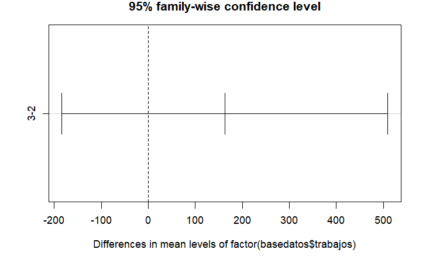

```r
plot(tukey_2)
```

##### 1.2.3.3 Two way ANOVA

La prueba ANOVA de dos vías se usa para evaluar simultáneamente el efecto de dos variables de agrupación (A y B) en una variable de respuesta. Toma en consideración dos grupos categóricos.

```r
anova_3 <- aov(basedatos$B1P02B06A ~ factor(basedatos$trabajos)*factor(basedatos$tamano))
```

```r
TukeyHSD(anova_3)
```

```
  Tukey multiple comparisons of means
    95% family-wise confidence level

Fit: aov(formula = basedatos$B1P02B06A ~ factor(basedatos$trabajos) * factor(basedatos$tamano))

$`factor(basedatos$trabajos)`
          diff       lwr       upr     p adj
2-1 -4.2298973 -4.847631 -3.612163 0.0000000
3-1 -3.7146105 -5.940282 -1.488939 0.0002712
3-2  0.5152869 -1.724492  2.755066 0.8519462

$`factor(basedatos$tamano)`
          diff       lwr        upr     p adj
1-0  2.4580779 -2.340868  7.2570244 0.6293326
2-0  0.3070431 -4.749310  5.3633963 0.9998315
3-0 -2.2017008 -8.968814  4.5654122 0.9015791
4-0  1.7130946 -3.836411  7.2626002 0.9174266
2-1 -2.1510348 -3.825184 -0.4768857 0.0041796
3-1 -4.6597788 -9.458725  0.1391676 0.0618949
4-1 -0.7449834 -3.579252  2.0892856 0.9526501
3-2 -2.5087440 -7.565097  2.5476092 0.6574566
4-2  1.4060515 -1.845087  4.6571899 0.7629650
4-3  3.9147954 -1.634710  9.4643011 0.3041926

$`factor(basedatos$trabajos):factor(basedatos$tamano)`
                diff         lwr        upr     p adj
2:0-1:0   3.82765957 -12.0863626 19.7416818 0.9999686
3:0-1:0  -3.30000000 -38.6970513 32.0970513 1.0000000
1:1-1:0   8.74359761  -5.7188504 23.2060456 0.7675406
2:1-1:0   4.90163848  -9.5682292 19.3715062 0.9983143
3:1-1:0   5.18351648  -9.6589604 20.0259934 0.9976640
1:2-1:0  10.62592593  -5.1060969 26.3579487 0.5972787
2:2-1:0   1.90000000 -12.7159429 16.5159429 1.0000000
3:2-1:0   6.28823529 -11.9233974 24.4998680 0.9979303
1:3-1:0   3.70000000 -44.2278341 51.6278341 1.0000000
2:3-1:0   0.01034483 -15.6366853 15.6573750 1.0000000
3:3-1:0           NA          NA         NA        NA
1:4-1:0  -2.30000000 -37.6970513 33.0970513 1.0000000
2:4-1:0   4.22469136 -10.6654279 19.1148106 0.9997711
3:4-1:0   0.27142857 -22.2484944 22.7913516 1.0000000
```

[output cut: 76 more lines]

```
2:3-1:3  -3.68965517 -49.7793115 42.4000011 1.0000000
3:3-1:3           NA          NA         NA        NA
1:4-1:3  -6.00000000 -61.9676523 49.9676523 1.0000000
2:4-1:3   0.52469136 -45.3135298 46.3629125 1.0000000
3:4-1:3  -3.42857143 -52.2811435 45.4240006 1.0000000
3:3-2:3           NA          NA         NA        NA
1:4-2:3  -2.31034483 -35.1756819 30.5549923 1.0000000
2:4-2:3   4.21434653  -2.7781345 11.2068276 0.7715765
3:4-2:3   0.26108374 -18.0235019 18.5456693 1.0000000
1:4-3:3           NA          NA         NA        NA
2:4-3:3           NA          NA         NA        NA
3:4-3:3           NA          NA         NA        NA
2:4-1:4   6.52469136 -25.9870985 39.0364812 0.9999968
3:4-1:4   2.57142857 -34.0680005 39.2108576 1.0000000
3:4-2:4  -3.95326279 -21.5944694 13.6879438 0.9999869
```

[figure not shown]

[figure not shown]

[figure not shown]